# Breast_Cancer_Detection_Ram_ML_Assignment (1)

## **Project : Evaluate Breast Cancer Detection based on given features and Conditions**

Ten real-valued features are computed for each cell nucleus:

```
a) Radius (mean of distances from center to points on the perimeter)
b) Texture (standard deviation of gray-scale values)
c) Perimeter
d) Area
e) Smoothness (local variation in radius lengths)
f) Compactness (perimeter^2 / area - 1.0)
g) Concavity (severity of concave portions of the contour)
h) Concave points (number of concave portions of the contour)
i) Symmetry
j) Fractal dimension ("coastline approximation" - 1)
```

Based on above features and conditions predict the Breast Cancer Detection

## Using Machine Learning To Predict Diagnosis of a Breast Cancer

1. Identify the problem Breast cancer is the most common malignancy among women, accounting for nearly 1 in 3 cancers diagnosed among women in the United States, and it is the second leading cause of cancer death among women. Breast Cancer occurs as a results of abnormal growth of cells in the breast tissue, commonly referred to as a Tumor. A tumor does not mean cancer - tumors can be benign (not cancerous), pre-malignant (pre-cancerous), or malignant (cancerous). Tests such as MRI, mammogram, ultrasound and biopsy are commonly used to diagnose breast cancer performed.

1.1 Expected outcome Given breast cancer results from breast fine needle aspiration (FNA) test (is a quick and simple procedure to perform, which removes some fluid or cells from a breast lesion or cyst (a lump, sore or swelling) with a fine needle similar to a blood sample needle). Since this build a model that can classify a breast cancer tumor using two training classification:

1= Malignant (Cancerous) - Present 0= Benign (Not Cancerous) -Absent 1.2 Objective Since the labels in the data are discrete, the predication falls into two categories, (i.e. Malignant or benign). In machine learning this is a classification problem.

1.3 Identify data sources The Breast Cancer datasets is available machine learning repository maintained by the University of California, Irvine. The dataset contains 569 samples of malignant and benign tumor cells.

The first two columns in the dataset store the unique ID numbers of the samples and the corresponding diagnosis (M=malignant, B=benign), respectively. The columns 3-32 contain 30 real-value features that have been computed from digitized images of the cell nuclei, which can be used to build a model to predict whether a tumor is benign or malignant.

### Step 1: Imported Libraries

```python
import pandas as pd
import numpy as np
import seaborn as sns
from sklearn import tree
from matplotlib import pyplot as plt
from sklearn.preprocessing import LabelEncoder
from sklearn.preprocessing import StandardScaler, MinMaxScaler
from sklearn.model_selection import train_test_split
from sklearn.tree import DecisionTreeClassifier
from sklearn.metrics import confusion_matrix, accuracy_score,classification_report
from sklearn import svm
from sklearn.ensemble import BaggingClassifier, ExtraTreesClassifier
from sklearn.ensemble import RandomForestClassifier
from sklearn.ensemble import AdaBoostClassifier
from sklearn.tree import DecisionTreeClassifier
from sklearn.ensemble import GradientBoostingClassifier
import matplotlib.pyplot as plt
from sklearn.linear_model import LogisticRegression
from sklearn.svm import SVC
from sklearn.naive_bayes import GaussianNB
from sklearn.ensemble import RandomForestClassifier
import xgboost
```

### Step 2: Loaded Dataset

```python
# load dataset
df = pd.read_csv('data.csv')
```

```python
df.head()
```

|  | id | diagnosis | radius_mean | texture_mean | perimeter_mean | area_mean | smoothness_mean | compactness_mean | concavity_mean | concave points_mean | ... | texture_worst | perimeter_worst | area_worst | smoothness_worst | compactness_worst | concavity_worst | concave points_worst | symmetry_worst | fractal_dimension_worst | Unnamed: 32 |
| --- | --- | --- | --- | --- | --- | --- | --- | --- | --- | --- | --- | --- | --- | --- | --- | --- | --- | --- | --- | --- | --- |
| 0 | 842302 | M | 17.99 | 10.38 | 122.80 | 1001.0 | 0.11840 | 0.27760 | 0.3001 | 0.14710 | ... | 17.33 | 184.60 | 2019.0 | 0.1622 | 0.6656 | 0.7119 | 0.2654 | 0.4601 | 0.11890 | NaN |
| 1 | 842517 | M | 20.57 | 17.77 | 132.90 | 1326.0 | 0.08474 | 0.07864 | 0.0869 | 0.07017 | ... | 23.41 | 158.80 | 1956.0 | 0.1238 | 0.1866 | 0.2416 | 0.1860 | 0.2750 | 0.08902 | NaN |
| 2 | 84300903 | M | 19.69 | 21.25 | 130.00 | 1203.0 | 0.10960 | 0.15990 | 0.1974 | 0.12790 | ... | 25.53 | 152.50 | 1709.0 | 0.1444 | 0.4245 | 0.4504 | 0.2430 | 0.3613 | 0.08758 | NaN |
| 3 | 84348301 | M | 11.42 | 20.38 | 77.58 | 386.1 | 0.14250 | 0.28390 | 0.2414 | 0.10520 | ... | 26.50 | 98.87 | 567.7 | 0.2098 | 0.8663 | 0.6869 | 0.2575 | 0.6638 | 0.17300 | NaN |
| 4 | 84358402 | M | 20.29 | 14.34 | 135.10 | 1297.0 | 0.10030 | 0.13280 | 0.1980 | 0.10430 | ... | 16.67 | 152.20 | 1575.0 | 0.1374 | 0.2050 | 0.4000 | 0.1625 | 0.2364 | 0.07678 | NaN |

5 rows × 33 columns

```python
df.info()
```

```
<class 'pandas.core.frame.DataFrame'>
RangeIndex: 569 entries, 0 to 568
Data columns (total 33 columns):
 #   Column                   Non-Null Count  Dtype
---  ------                   --------------  -----
 0   id                       569 non-null    int64
 1   diagnosis                569 non-null    object
 2   radius_mean              569 non-null    float64
 3   texture_mean             569 non-null    float64
 4   perimeter_mean           569 non-null    float64
 5   area_mean                569 non-null    float64
 6   smoothness_mean          569 non-null    float64
 7   compactness_mean         569 non-null    float64
 8   concavity_mean           569 non-null    float64
 9   concave points_mean      569 non-null    float64
```

[output cut: 25 more lines]

```python
df.shape
```

```
(569, 33)
```

```python
# check category level of all columns
for col in df.columns:
    print("----------------{}-----------------------".format(col))
    print(df[col].value_counts())
    print()
```

```
----------------id-----------------------
842302     1
90250      1
901315     1
9013579    1
9013594    1
          ..
873885     1
873843     1
873701     1
873593     1
92751      1
Name: id, Length: 569, dtype: int64

----------------diagnosis-----------------------
B    357
M    212
Name: diagnosis, dtype: int64

----------------radius_mean-----------------------
12.34    4
11.71    3
12.46    3
13.05    3
10.26    3
        ..
12.23    1
14.45    1
19.18    1
18.08    1
7.76     1
Name: radius_mean, Length: 456, dtype: int64

----------------texture_mean-----------------------
20.52    3
16.85    3
16.84    3
19.83    3
14.93    3
        ..
```

[output cut: 386 more lines]

```
0.07427    3
0.09026    2
0.12970    2
0.08174    2
0.10550    2
          ..
0.06938    1
0.07697    1
0.09772    1
0.08631    1
0.07039    1
Name: fractal_dimension_worst, Length: 535, dtype: int64

----------------Unnamed: 32-----------------------
Series([], Name: Unnamed: 32, dtype: int64)
```

## Step 3: **Data Preprocessing**

```python
# checking missing values
df.isnull().sum()
```

```
id                           0
diagnosis                    0
radius_mean                  0
texture_mean                 0
perimeter_mean               0
area_mean                    0
smoothness_mean              0
compactness_mean             0
concavity_mean               0
concave points_mean          0
symmetry_mean                0
fractal_dimension_mean       0
radius_se                    0
texture_se                   0
perimeter_se                 0
area_se                      0
smoothness_se                0
compactness_se               0
concavity_se                 0
concave points_se            0
symmetry_se                  0
fractal_dimension_se         0
radius_worst                 0
texture_worst                0
perimeter_worst              0
area_worst                   0
smoothness_worst             0
compactness_worst            0
concavity_worst              0
concave points_worst         0
symmetry_worst               0
fractal_dimension_worst      0
Unnamed: 32                569
dtype: int64
```

```python
df.isna().sum()
```

```
id                           0
diagnosis                    0
radius_mean                  0
texture_mean                 0
perimeter_mean               0
area_mean                    0
smoothness_mean              0
compactness_mean             0
concavity_mean               0
concave points_mean          0
symmetry_mean                0
fractal_dimension_mean       0
radius_se                    0
texture_se                   0
perimeter_se                 0
area_se                      0
smoothness_se                0
compactness_se               0
concavity_se                 0
concave points_se            0
symmetry_se                  0
fractal_dimension_se         0
radius_worst                 0
texture_worst                0
perimeter_worst              0
area_worst                   0
smoothness_worst             0
compactness_worst            0
concavity_worst              0
concave points_worst         0
symmetry_worst               0
fractal_dimension_worst      0
Unnamed: 32                569
dtype: int64
```

```python
df = df.dropna(axis=1)
```

```python
# checking basic info
df.info()
```

```
<class 'pandas.core.frame.DataFrame'>
RangeIndex: 569 entries, 0 to 568
Data columns (total 32 columns):
 #   Column                   Non-Null Count  Dtype
---  ------                   --------------  -----
 0   id                       569 non-null    int64
 1   diagnosis                569 non-null    object
 2   radius_mean              569 non-null    float64
 3   texture_mean             569 non-null    float64
 4   perimeter_mean           569 non-null    float64
 5   area_mean                569 non-null    float64
 6   smoothness_mean          569 non-null    float64
 7   compactness_mean         569 non-null    float64
 8   concavity_mean           569 non-null    float64
 9   concave points_mean      569 non-null    float64
```

[output cut: 24 more lines]

```python
## counting of malignant and benign diagnosis categories
df['diagnosis'].value_counts()
```

```
B    357
M    212
Name: diagnosis, dtype: int64
```

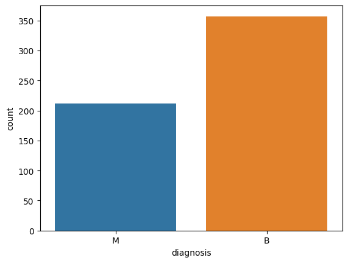

```python
sns.countplot(x='diagnosis', data=df, label='count')

# Display the chart
plt.show()
```

```python
df.dtypes
```

```
id                           int64
diagnosis                   object
radius_mean                float64
texture_mean               float64
perimeter_mean             float64
area_mean                  float64
smoothness_mean            float64
compactness_mean           float64
concavity_mean             float64
concave points_mean        float64
symmetry_mean              float64
fractal_dimension_mean     float64
radius_se                  float64
texture_se                 float64
perimeter_se               float64
area_se                    float64
smoothness_se              float64
compactness_se             float64
concavity_se               float64
concave points_se          float64
symmetry_se                float64
fractal_dimension_se       float64
radius_worst               float64
texture_worst              float64
perimeter_worst            float64
area_worst                 float64
smoothness_worst           float64
compactness_worst          float64
concavity_worst            float64
concave points_worst       float64
symmetry_worst             float64
fractal_dimension_worst    float64
dtype: object
```

```python
# encoding Categorical data
from sklearn.preprocessing import LabelEncoder
le = LabelEncoder()
df.iloc[:,1] = le.fit_transform(df.iloc[:,1].values)
```

```python
df.head()
```

|  | id | diagnosis | radius_mean | texture_mean | perimeter_mean | area_mean | smoothness_mean | compactness_mean | concavity_mean | concave points_mean | ... | radius_worst | texture_worst | perimeter_worst | area_worst | smoothness_worst | compactness_worst | concavity_worst | concave points_worst | symmetry_worst | fractal_dimension_worst |
| --- | --- | --- | --- | --- | --- | --- | --- | --- | --- | --- | --- | --- | --- | --- | --- | --- | --- | --- | --- | --- | --- |
| 0 | 842302 | 1 | 17.99 | 10.38 | 122.80 | 1001.0 | 0.11840 | 0.27760 | 0.3001 | 0.14710 | ... | 25.38 | 17.33 | 184.60 | 2019.0 | 0.1622 | 0.6656 | 0.7119 | 0.2654 | 0.4601 | 0.11890 |
| 1 | 842517 | 1 | 20.57 | 17.77 | 132.90 | 1326.0 | 0.08474 | 0.07864 | 0.0869 | 0.07017 | ... | 24.99 | 23.41 | 158.80 | 1956.0 | 0.1238 | 0.1866 | 0.2416 | 0.1860 | 0.2750 | 0.08902 |
| 2 | 84300903 | 1 | 19.69 | 21.25 | 130.00 | 1203.0 | 0.10960 | 0.15990 | 0.1974 | 0.12790 | ... | 23.57 | 25.53 | 152.50 | 1709.0 | 0.1444 | 0.4245 | 0.4504 | 0.2430 | 0.3613 | 0.08758 |
| 3 | 84348301 | 1 | 11.42 | 20.38 | 77.58 | 386.1 | 0.14250 | 0.28390 | 0.2414 | 0.10520 | ... | 14.91 | 26.50 | 98.87 | 567.7 | 0.2098 | 0.8663 | 0.6869 | 0.2575 | 0.6638 | 0.17300 |
| 4 | 84358402 | 1 | 20.29 | 14.34 | 135.10 | 1297.0 | 0.10030 | 0.13280 | 0.1980 | 0.10430 | ... | 22.54 | 16.67 | 152.20 | 1575.0 | 0.1374 | 0.2050 | 0.4000 | 0.1625 | 0.2364 | 0.07678 |

5 rows × 32 columns

## Need to **separate** columns into smaller dataframes to perform visualization

```python
data_mean=df.iloc[:,1:11]
```

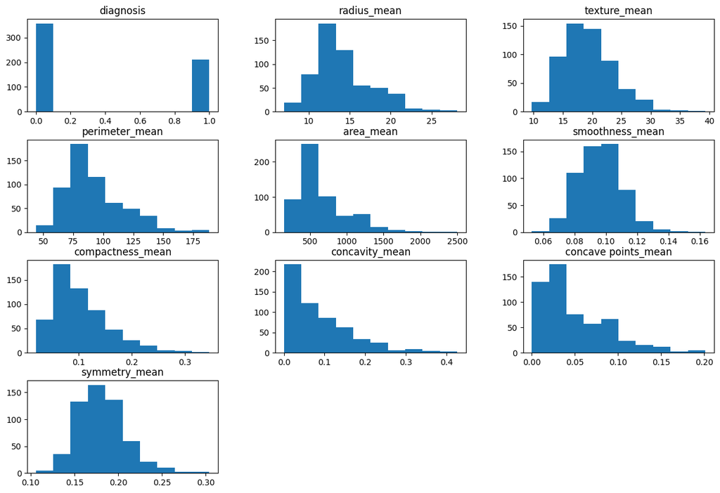

```python
#Ploted histograms of CUT1 variables
hist_mean=data_mean.hist(bins=10, figsize=(15, 10),grid=False,)
```

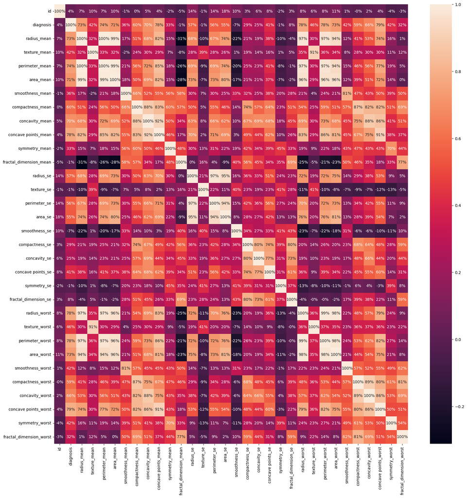

```python
#Heatmap
plt.figure(figsize=(20,20))
sns.heatmap(df.corr(),annot=True, fmt = '.0%')
```

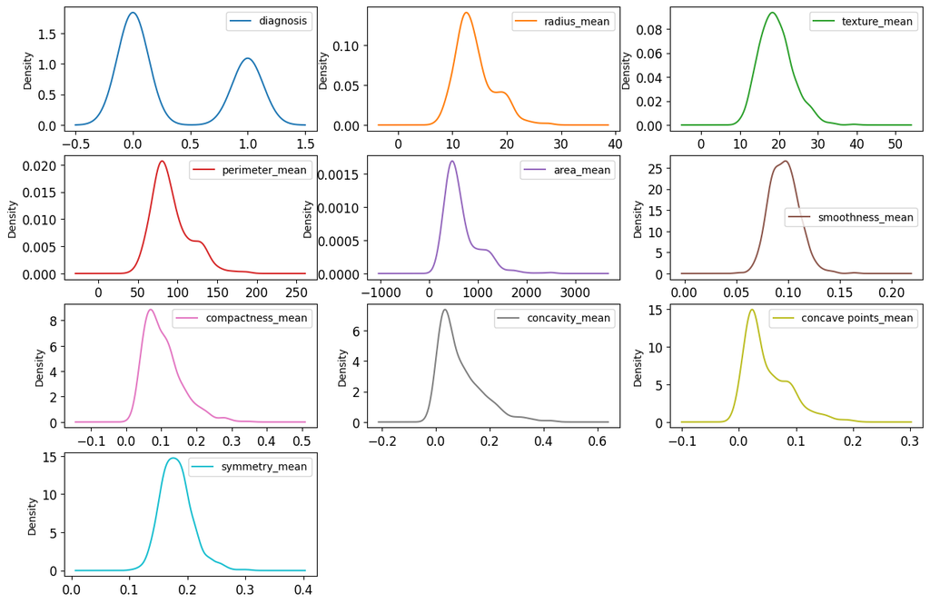

```python
#Density Plots
plt = data_mean.plot(kind= 'density', subplots=True, layout=(4,3), sharex=False,
                     sharey=False,fontsize=12, figsize=(15,10))
```

```python
# Apply label encoder to convert categories into numeric values
le = LabelEncoder()

for x in df.columns:
    df[x]=le.fit_transform(df[x])
    le_name = dict(zip(le.classes_, le.transform(le.classes_)))
    print("--------------------------------------------------")
    print("Feature: ", x)
    print("Mapping: ", le_name)
```

[output not shown]

[output cut: 41 more lines]

[output not shown]

```python
df.head()
```

|  | id | diagnosis | radius_mean | texture_mean | perimeter_mean | area_mean | smoothness_mean | compactness_mean | concavity_mean | concave points_mean | ... | radius_worst | texture_worst | perimeter_worst | area_worst | smoothness_worst | compactness_worst | concavity_worst | concave points_worst | symmetry_worst | fractal_dimension_worst |
| --- | --- | --- | --- | --- | --- | --- | --- | --- | --- | --- | --- | --- | --- | --- | --- | --- | --- | --- | --- | --- | --- |
| 0 | 41 | 1 | 370 | 1 | 455 | 452 | 444 | 531 | 521 | 526 | ... | 425 | 41 | 497 | 516 | 358 | 516 | 520 | 483 | 485 | 506 |
| 1 | 42 | 1 | 426 | 186 | 486 | 513 | 120 | 215 | 321 | 396 | ... | 419 | 199 | 465 | 511 | 158 | 210 | 278 | 401 | 222 | 375 |
| 2 | 488 | 1 | 406 | 324 | 478 | 487 | 403 | 459 | 478 | 516 | ... | 399 | 261 | 455 | 491 | 287 | 464 | 438 | 468 | 445 | 361 |
| 3 | 489 | 1 | 98 | 297 | 164 | 95 | 471 | 533 | 507 | 493 | ... | 215 | 298 | 281 | 194 | 408 | 524 | 511 | 479 | 499 | 533 |
| 4 | 490 | 1 | 418 | 60 | 493 | 506 | 332 | 414 | 480 | 492 | ... | 381 | 28 | 453 | 470 | 239 | 245 | 415 | 363 | 81 | 216 |

5 rows × 32 columns

## **Step 4: Seprate X and y**

```python
X = df.iloc[  :  ,  2:]  #independent variables
y = df.iloc[  :  ,   1]  #dependent variable
```

## **Step 5: Spliting the Data**

```python
# train test split

x = df.drop(['diagnosis'], axis=1)
y = df['diagnosis'].values

x_train,x_test,y_train,y_test = train_test_split(x,y,test_size=0.2, random_state=0)
```

```python
# train test split

# Split the data into test and train
X_train, X_test, y_train, y_test = train_test_split(X,
                                                    y,
                                                    test_size=0.3,
                                                    random_state=10)
# verify spliting data
print("Total Data: ", df.shape)
print("Train X: ", X_train.shape)
print("Train y: ", y_train.shape)
print("Test X: ", X_test.shape)
print("Test y: ", y_test.shape)
```

```
Total Data:  (569, 32)
Train X:  (398, 30)
Train y:  (398,)
Test X:  (171, 30)
Test y:  (171,)
```

### **Step 6: Data Normalisation**

```python
# perform data normalisation

# create object for scaler
scaler = MinMaxScaler()

# fit the train data on scaler object
scaler.fit(X_train)

X_train_scale = scaler.transform(X_train)
X_test_scale = scaler.transform(X_test)
```

```python
# compare normal and scale data
print(X_train.iloc[0])
print(X_train_scale[0])
```

```
radius_mean                156
texture_mean               184
perimeter_mean             209
area_mean                  191
smoothness_mean            374
compactness_mean           409
concavity_mean             300
concave points_mean        209
symmetry_mean              218
fractal_dimension_mean     434
radius_se                   43
texture_se                 375
perimeter_se               244
area_se                     87
smoothness_se              482
compactness_se             404
concavity_se               435
concave points_se          284
symmetry_se                333
fractal_dimension_se       481
radius_worst               112
texture_worst              182
perimeter_worst            204
area_worst                 137
smoothness_worst           290
compactness_worst          329
concavity_worst            276
concave points_worst       143
symmetry_worst             147
fractal_dimension_worst    417
Name: 431, dtype: int64
[0.34285714 0.3836478  0.40115163 0.35501859 0.79237288 0.76448598
 0.55970149 0.38632163 0.50580046 0.87148594 0.07977737 0.72533849
 0.45864662 0.1634981  0.88256881 0.74953618 0.82075472 0.56237624
 0.67137097 0.88581952 0.24561404 0.35559921 0.39766082 0.25230203
 0.71007371 0.62239089 0.51396648 0.29243354 0.29458918 0.78089888]
```

# **Step 7: Model Building**

```python
# Logistic Regression
reg = LogisticRegression()
reg.fit(X_train,y_train)
print("Logistic Regression accuracy : {:.2f}%".format(reg.score(X_test,y_test)*100))
```

```
Logistic Regression accuracy : 92.98%
```

```python
# support vector classifier
svm = SVC(random_state=1)
svm.fit(X_train,y_train)
print("SVC accuracy : {:.2f}%".format(svm.score(X_test,y_test)*100))
```

```
SVC accuracy : 99.42%
```

```python
# Naive Bayes
nb = GaussianNB()
nb.fit(X_train,y_train)
print(" Naive Bayes accuracy : {:.2f}%".format(nb.score(X_test,y_test)*100))
```

```
 Naive Bayes accuracy : 94.74%
```

```python
#Random Forest
rf = RandomForestClassifier(n_estimators=1000,random_state=1)
rf.fit(X_train,y_train)
print("Random Forest Classifier accuracy : {:.2f}%".format(rf.score(X_test,y_test)*100))
```

```
Random Forest Classifier accuracy : 98.25%
```

```python
xg = xgboost.XGBClassifier()
xg.fit(X_train,y_train)
print("XGboost accuracy : {:.2f}%".format(xg.score(X_test,y_test)*100))
```

```
XGboost accuracy : 97.66%
```

# **Step 7.a: Model Building**

**1. Decision Tree**

```python
# create model object  with default parameter
model_dt = DecisionTreeClassifier()

# create model object  with custom parameter
# model_dt = DecisionTreeClassifier(criterion='gini',
#                                   random_state=10,
#                                   min_samples_leaf=5,
#                                   min_samples_split=20,
#                                   max_leaf_nodes=15,
#                                   max_depth=6)

#fit the model on the data and predict the values
model_dt.fit(X_train, y_train)
```

```
DecisionTreeClassifier()
```

```python
model_dt.get_depth()
```

```
7
```

```python
# prediction on Test Data
y_pred= model_dt.predict(X_test)

print(list(zip(y_test,y_pred)))
```

```
[(1, 1), (0, 0), (0, 0), (1, 1), (0, 0), (0, 1), (0, 0), (0, 0), (1, 1), (1, 1), (0, 0), (0, 0), (1, 1), (0, 0), (1, 1), (1, 1), (0, 0), (0, 1), (0, 0), (0, 0), (1, 1), (1, 1), (0, 0), (0, 0), (1, 1), (1, 1), (0, 0), (1, 1), (0, 0), (0, 0), (0, 0), (0, 0), (1, 1), (0, 0), (0, 0), (0, 0), (0, 0), (0,…
```

```python
# confusion matrix
print("---------Confusion Matrix------------")
print(confusion_matrix(y_test, y_pred))
print()
print("---------Accuracy Score------------")
print(accuracy_score(y_test,y_pred))
print()
print("---------Classification Report------------")
print(classification_report(y_test,y_pred))
```

```
---------Confusion Matrix------------
[[99 13]
 [ 3 56]]

---------Accuracy Score------------
0.9064327485380117

---------Classification Report------------
              precision    recall  f1-score   support

           0       0.97      0.88      0.93       112
           1       0.81      0.95      0.87        59

    accuracy                           0.91       171
   macro avg       0.89      0.92      0.90       171
weighted avg       0.92      0.91      0.91       171
```

```python
# feature importance for all columns
# total will be 1

print(list(zip(df.columns, model_dt.feature_importances_)))
```

```
[('id', 0.007078386910319681), ('diagnosis', 0.0), ('radius_mean', 0.019599939797665947), ('texture_mean', 0.0), ('perimeter_mean', 0.007078386910319681), ('area_mean', 0.0), ('smoothness_mean', 0.0), ('compactness_mean', 0.0053087901827397616), ('concavity_mean', 0.0), ('concave points_mean', 0.0),…
```

```python
df.columns[2:]
```

```
Index(['radius_mean', 'texture_mean', 'perimeter_mean', 'area_mean',
       'smoothness_mean', 'compactness_mean', 'concavity_mean',
       'concave points_mean', 'symmetry_mean', 'fractal_dimension_mean',
       'radius_se', 'texture_se', 'perimeter_se', 'area_se', 'smoothness_se',
       'compactness_se', 'concavity_se', 'concave points_se', 'symmetry_se',
       'fractal_dimension_se', 'radius_worst', 'texture_worst',
       'perimeter_worst', 'area_worst', 'smoothness_worst',
       'compactness_worst', 'concavity_worst', 'concave points_worst',
       'symmetry_worst', 'fractal_dimension_worst'],
      dtype='object')
```

```python
# from sklearn import tree
# import graphviz

# with open("model_DecisionTree.txt", "w") as f:
#     f = tree.export_graphviz(model_dt, feature_names=data_df.columns[2:], out_file=f)

# # generate the file and upload the code in webgraphviz.com to plot the decision tree
```

```python
#%%time

# it will take 5 to 6 mins to create image so wait.....
#fig = plt.figure(figsize=(500,400))
#dot_data = tree.plot_tree(model_dt,
                   #feature_names=list(df.columns[2:]),
                   #class_names=list(df.columns[2]),
                   #filled=True)
#plt.savefig("base_model.jpeg")
```

### 2. USING SVM

```python
# create svm object
svc_model = svm.SVC()

# train svm model on train dataset
svc_model.fit(X_train, y_train)

# predict on test dataset
y_pred=svc_model.predict(X_test)
```

```python
# confusion matrix
print("---------Confusion Matrix------------")
print(confusion_matrix(y_test, y_pred))
print()
print("---------Accuracy Score------------")
print(accuracy_score(y_test,y_pred))
print()
print("---------Classification Report------------")
print(classification_report(y_test,y_pred))
```

```
---------Confusion Matrix------------
[[111   1]
 [  0  59]]

---------Accuracy Score------------
0.9941520467836257

---------Classification Report------------
              precision    recall  f1-score   support

           0       1.00      0.99      1.00       112
           1       0.98      1.00      0.99        59

    accuracy                           0.99       171
   macro avg       0.99      1.00      0.99       171
weighted avg       0.99      0.99      0.99       171
```

## Bagging Approach

Running Bagging Classifier model

```python
#predicting using the Bagging_Classifier
model =BaggingClassifier(n_estimators=10, random_state=10)

# try to increase the n_estimator  # min_samples_leaf=1, max_depth=None

#fit the model on the data and predict the values
model = model.fit(X_train,y_train)

y_pred=model.predict(X_test)
```

```python
# confusion matrix  {'acc': 0, 'good': 1, 'unacc': 2, 'vgood': 3}
print("---------Confusion Matrix------------")
print(confusion_matrix(y_test, y_pred))
print()
print("---------Accuracy Score------------")
print(accuracy_score(y_test,y_pred))
print()
print("---------Classification Report------------")
print(classification_report(y_test,y_pred))
```

```
---------Confusion Matrix------------
[[109   3]
 [  3  56]]

---------Accuracy Score------------
0.9649122807017544

---------Classification Report------------
              precision    recall  f1-score   support

           0       0.97      0.97      0.97       112
           1       0.95      0.95      0.95        59

    accuracy                           0.96       171
   macro avg       0.96      0.96      0.96       171
weighted avg       0.96      0.96      0.96       171
```

## Running Random Forest model

```python
#predicting using the Random_Forest_Classifier
model_rf = RandomForestClassifier(n_estimators=5000,
                                          random_state=10,
                                         verbose=1,
                                         n_jobs=-1)

#fit the model on the data and predict the values
model_rf.fit(X_train,y_train)

y_pred = model_rf.predict(X_test)
```

[output not shown]

```python
# confusion matrix  {'acc': 0, 'good': 1, 'unacc': 2, 'vgood': 3}
print("---------Confusion Matrix------------")
print(confusion_matrix(y_test, y_pred))
print()
print("---------Accuracy Score------------")
print(accuracy_score(y_test,y_pred))
print()
print("---------Classification Report------------")
print(classification_report(y_test,y_pred))
```

```
---------Confusion Matrix------------
[[109   3]
 [  0  59]]

---------Accuracy Score------------
0.9824561403508771

---------Classification Report------------
              precision    recall  f1-score   support

           0       1.00      0.97      0.99       112
           1       0.95      1.00      0.98        59

    accuracy                           0.98       171
   macro avg       0.98      0.99      0.98       171
weighted avg       0.98      0.98      0.98       171
```

## Conclusion

- As per above anlysis we can say that the SVM model performs better on test data